# Классификатор комментариев

Интернет-магазин запускает новый сервис. Теперь пользователи могут редактировать и дополнять описания товаров, как в вики-сообществах. То есть клиенты предлагают свои правки и комментируют изменения других. Магазину нужен инструмент, который будет искать токсичные комментарии и отправлять их на модерацию.

**Цель проекта**

Обучить модель классифицировать комментарии на позитивные и негативные. Метрика качества - **F1**, которая должна быть не менее 0.75.

В нашем распоряжении набор данных с разметкой о токсичности правок.

**Описание данных**

Данные находятся в файле `toxic_comments.csv`. Столбец *text* в нём содержит текст комментария, а *toxic* — целевой признак.

## Подготовка данных

```python
#загружаем необходимые библиотеки
!pip install catboost
!pip install lightgbm
!pip install wordcloud

import pandas as pd
import matplotlib.pyplot as plt
import numpy as np
import warnings
import re
import nltk
import spacy
import en_core_web_sm

from sklearn.model_selection import train_test_split, cross_val_score
from sklearn.linear_model import LogisticRegression
from sklearn.tree import DecisionTreeClassifier
from sklearn.ensemble import RandomForestClassifier
from sklearn.model_selection import RandomizedSearchCV
from sklearn.metrics import f1_score
from sklearn.feature_extraction.text import TfidfVectorizer

from nltk.stem import WordNetLemmatizer
from nltk.corpus import stopwords

from tqdm.notebook import tqdm

from wordcloud import WordCloud

from catboost import CatBoostRegressor

from lightgbm import LGBMClassifier

nltk.download('punkt')
nltk.download('wordnet')
nltk.download('omw-1.4')
nltk.download('stopwords')

tqdm.pandas()
```

[output not shown]

[output not shown]

```python
RANDOM = 123
stopwords = stopwords.words('english')
warnings.filterwarnings('ignore')
model_list = []
f_score_list = []
best_params = []
```

```python
#загружаем датасет
try:
    data = pd.read_csv('/datasets/toxic_comments.csv', index_col=0)
except:
    data = pd.read_csv('/Users/amirk/Downloads/toxic_comments.csv', index_col=0)
```

```python
data
```

|  | text | toxic |
| --- | --- | --- |
| 0 | Explanation\nWhy the edits made under my usern... | 0 |
| 1 | D'aww! He matches this background colour I'm s... | 0 |
| 2 | Hey man, I'm really not trying to edit war. It... | 0 |
| 3 | "\nMore\nI can't make any real suggestions on ... | 0 |
| 4 | You, sir, are my hero. Any chance you remember... | 0 |
| ... | ... | ... |
| 159446 | ":::::And for the second time of asking, when ... | 0 |
| 159447 | You should be ashamed of yourself \n\nThat is ... | 0 |
| 159448 | Spitzer \n\nUmm, theres no actual article for ... | 0 |
| 159449 | And it looks like it was actually you who put ... | 0 |
| 159450 | "\nAnd ... I really don't think you understand... | 0 |

159292 rows × 2 columns

```python
data.info()
```

```
<class 'pandas.core.frame.DataFrame'>
Int64Index: 159292 entries, 0 to 159450
Data columns (total 2 columns):
 #   Column  Non-Null Count   Dtype
---  ------  --------------   -----
 0   text    159292 non-null  object
 1   toxic   159292 non-null  int64
dtypes: int64(1), object(1)
memory usage: 3.6+ MB
```

```python
# проверим баланс классов
data['toxic'].value_counts()
```

```
0    143106
1     16186
Name: toxic, dtype: int64
```

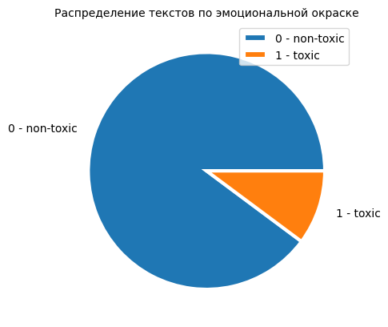

```python
plt.pie(data['toxic'].value_counts(),
        labels=['0 - non-toxic', '1 - toxic'],
        labeldistance=1.15,
        wedgeprops = { 'linewidth' : 3, 'edgecolor' : 'white' })
plt.title('Распределение текстов по эмоциональной окраске', fontsize=10)
plt.legend(fontsize=10)
plt.show()
```

Нам необходимо выполнить токенизацию и лемматизацию, избавиться от стоп слов и ненужных символов. Данные преобразования не подразумевают утечки данных, поэтому выполним данные преобразования до разделения на тест и трейн.

```python
#выполним токенизацию
nlp = spacy.load("en_core_web_sm")
data['a'] = data['text'].progress_apply(lambda x: nlp(x))
data['tokenized'] = data['a'].progress_apply(lambda x: " ".join([token.lemma_ for token in x]))
```

```python
# избавимся от ненужных символов
data['prepared'] = data['tokenized'].progress_apply(lambda x: ' '.join(re.sub(r"[^a-zA-Z]", ' ', x).split()))
```

```python
# приведем все к нижнему регистру для уменьшения количества уникальных слов
data['prepared'] = data['prepared'].str.lower()
```

```python
data['prepared']
```

```
0         explanation why the edit make under my usernam...
1         d aww he match this background colour i be see...
2         hey man i be really not try to edit war it be ...
3         more i can not make any real suggestion on imp...
4         you sir be my hero any chance you remember wha...
                                ...
159446    and for the second time of asking when your vi...
159447    you should be ashamed of yourself that be a ho...
159448    spitzer umm there s no actual article for pros...
159449    and it look like it be actually you who put on...
159450    and i really do not think you understand i com...
Name: prepared, Length: 159292, dtype: object
```

Посмотрим наиболее часто встречающиеся слова в текстах, отмеченных как **toxic - 1** и **non-toxic - 0**

```python
# создадим строки с токсичным и нетоксичным текстом
words_toxic = ' '.join(data[data['toxic'] == 1]['prepared'])
words_non_toxic = ' '.join(data[data['toxic'] == 0]['prepared'])

# создадим объект облако слов
cloud = WordCloud(stopwords=stopwords)

#создадим функцию для выводв облака слов на экран
def cloud_print(words, cloud):
    fig = plt.subplots(figsize=(10,5))
    plt.imshow(cloud.generate(words))
    plt.axis('off')
```

```
Наиболее часто встречающиеся слова в токсичном тексте
```

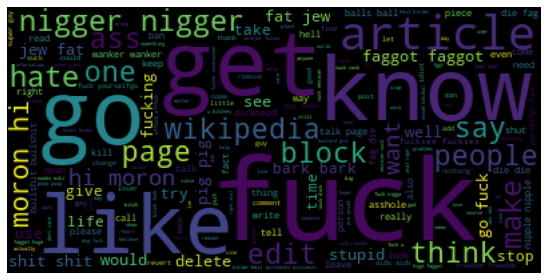

```python
print('Наиболее часто встречающиеся слова в токсичном тексте')
cloud_print(words_toxic, cloud)
```

```
Наиболее часто встречающиеся слова в нетоксичном тексте
```

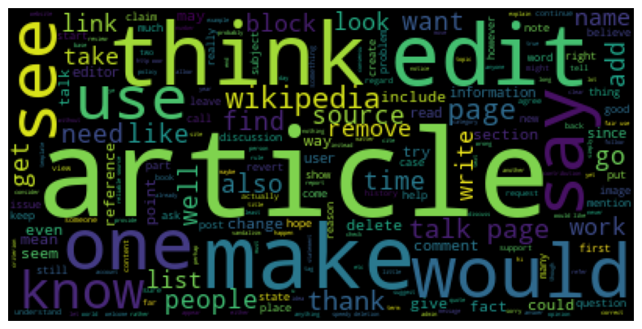

```python
print('Наиболее часто встречающиеся слова в нетоксичном тексте')
cloud_print(words_non_toxic, cloud)
```

```python
stopwords.extend(['n'])
```

```python
#разделим данные на таргет и фичи
X = data['text']
y = data['toxic']
```

```python
# разобьем данные на 2 выборки: обучающую и тестовую (80%, 20%).
X_train, X_test, y_train, y_test = train_test_split(X, y, test_size=0.20, random_state=RANDOM, stratify=y)
```

```python
# проведем векторизацию тренировочной выборки
count_tf_idf = TfidfVectorizer(stop_words=stopwords) # stopwords - список стоп-слов
tf_idf_train = count_tf_idf.fit_transform(X_train)
```

```python
tf_idf_train
```

```
<127433x165297 sparse matrix of type '<class 'numpy.float64'>'
	with 3573169 stored elements in Compressed Sparse Row format>
```

**Данные готовы к работе!**

## Обучение моделей

### LGBM model

```python
# напишем функцию для поиска наилучшей модели через кроссвалидацию
def best_model_lgbm(X_train, y_train):
    model = LGBMClassifier(learning_rate=0.65)
    params = {'n_estimators':range(20, 200, 20), 'max_depth':range(1,15), 'min_data_in_leaf':range(1,40)}
    grid_model = RandomizedSearchCV(model,
                                    params,
                                    cv=5,
                                    scoring='f1',
                                    error_score='raise',
                                    n_jobs=-1,
                                    verbose=1,
                                    random_state=RANDOM)
    grid_model.fit(X_train, y_train)
    model_list.append(model.__class__.__name__)
    f_score_list.append(grid_model.best_score_)
    best_params.append(grid_model.best_params_)
    print('Значение F1 = ', grid_model.best_score_)
    print('Лучшие параметры модели:', grid_model.best_params_)
    return grid_model
```

```python
lgbm = best_model_lgbm(tf_idf_train, y_train)
```

```
Fitting 5 folds for each of 10 candidates, totalling 50 fits
[LightGBM] [Warning] min_data_in_leaf is set=35, min_child_samples=20 will be ignored. Current value: min_data_in_leaf=35
Значение F1 =  0.7470571130113728
Лучшие параметры модели: {'n_estimators': 60, 'min_data_in_leaf': 35, 'max_depth': 12}
```

Лучшие гиперпараметры и метрика найдены!

### DecisionTreeClassifier model

Выполним аналогичные действия по подбору гиперпараметров и оценим модель на тренировочных данных

```python
def best_model_dtr(X_train, y_train):
    model = DecisionTreeClassifier()
    params = {'max_depth':range(1,10), 'min_samples_split':range(2,10), 'min_samples_leaf':range(1,10)}
    grid_model = RandomizedSearchCV(model,
                                    params,
                                    cv=5,
                                    scoring='f1',
                                    n_jobs=-1,
                                    verbose=1,
                                    random_state=RANDOM)
    grid_model.fit(X_train, y_train)
    model_list.append(model.__class__.__name__)
    f_score_list.append(grid_model.best_score_)
    best_params.append(grid_model.best_params_)
    print('Значение RMSE = ', abs(grid_model.best_score_))
    print('Лучшие параметры модели:', grid_model.best_params_)
    return grid_model
```

```python
dtr = best_model_dtr(tf_idf_train, y_train)
```

```
Fitting 5 folds for each of 10 candidates, totalling 50 fits
Значение RMSE =  0.5661851325329403
Лучшие параметры модели: {'min_samples_split': 3, 'min_samples_leaf': 7, 'max_depth': 9}
```

### LogisticRegression model

```python
def best_model_lr(X_train, y_train):
    model = LogisticRegression(random_state=RANDOM)
    params = {'max_iter':range(100,1100,100), 'C':[1, 10, 100, 1000]}
    grid_model = RandomizedSearchCV(model,
                                    params,
                                    cv=5,
                                    scoring='f1',
                                    error_score='raise',
                                    n_jobs=-1,
                                    verbose=1,
                                    random_state=RANDOM)
    grid_model.fit(X_train, y_train)
    model_list.append(model.__class__.__name__)
    f_score_list.append(grid_model.best_score_)
    best_params.append(grid_model.best_params_)
    print('Значение F1 = ', grid_model.best_score_)
    print('Лучшие параметры модели:', grid_model.best_params_)
    return grid_model
```

```python
lr = best_model_lr(tf_idf_train, y_train)
```

```
Fitting 5 folds for each of 10 candidates, totalling 50 fits
Значение F1 =  0.76352547980537
Лучшие параметры модели: {'max_iter': 100, 'C': 10}
```

```python
# создадим сводную таблицу по результатам теста
top_list_df = pd.DataFrame({'Model':model_list,
                            'F1 score':f_score_list,
                            'Best parameters':best_params }).sort_values(by='F1 score', ascending=False).reset_index(drop=True)
top_list_df
```

|  | Model | F1 score | Best parameters |
| --- | --- | --- | --- |
| 0 | LogisticRegression | 0.763525 | {'max_iter': 100, 'C': 10} |
| 1 | LGBMClassifier | 0.747057 | {'n_estimators': 60, 'min_data_in_leaf': 35, '... |
| 2 | DecisionTreeClassifier | 0.566185 | {'min_samples_split': 3, 'min_samples_leaf': 7... |

В ходе исследования мы обучили 3 модели для обнаружения токсичных комментариев. Наилучший показатель метрики F1 оказался у модели LogisticRegression.

Проверим работу модели на тестовых данных!

```python
def check_model(model, X_data, y_data):
    tf_idf = count_tf_idf.transform(X_data)
    predict = model.predict(tf_idf)
    print(f"Значение F1 метрики для лучшей модели на тестовых данных равно {f1_score(predict, y_data):.2}")
```

```python
check_model(lr, X_test, y_test)
```

```
Значение F1 метрики для лучшей модели на тестовых данных равно 0.78
```

Лучшей моделью для обнаружения токсичных комментариев признана модель LogisticRegression c гиперпараметрами max_iter = 100, C = 10. Итоговое значение метрики F1 на тестовых данных составило 0.78 Модель успешно прошла тестирование!

## Выводы

Перед нами стояла задача для поиска модели, которая могла бы классифицировать комментарии на позитивные и негативные в новом сервисе интернет-магазина «Викишоп» для последующей отправки токсичных отзывов на модерацию. Модель должна была иметь метрику качества *F1* не меньше 0.75.

Мы обучили 3 модели для обнаружения токсичных комментариев. Наилучший показатель метрики F1 оказался у модели LogisticRegression.

[output not shown]

Таким образом, лучшей моделью для обнаружения токсичных комментариев признана модель LogisticRegression c гиперпараметрами max_iter = 100, C = 10. Итоговое значение метрики F1 на тестовых данных составило 0.78. Модель успешно прошла тестирование!